# M507_Individual_Final_Project_GH1026415

## Business Context

Our company loses 10% to 15% of its customers each year to its competitors. Even though we can't realistically keep all of its customers, devoting time to the customers who are more likely to leave is key to customer retention. In fact, keeping customers is much more feasible than acquiring new customers. For this purpose, as the data scientist of this company, I will build a deep learning pipeline to predict which customers are more likely to leave, so that we can put more effort into those cusomers.

The dataset was downloaded from the following link on kaggle:

https://www.kaggle.com/datasets/blastchar/telco-customer-churn

# List of contents

### 11. Limitations of the pipeline

## 1. Importing libraries, packages, and modules

```python
#!pip install tensorflow
import time
from sklearn.model_selection import train_test_split
from sklearn.preprocessing import MinMaxScaler, OneHotEncoder
from sklearn.tree import DecisionTreeClassifier, plot_tree
from sklearn.compose import ColumnTransformer
from sklearn.metrics import f1_score, classification_report
import pandas as pd
from matplotlib import pyplot as plt
import numpy as np
from sklearn.model_selection import GridSearchCV
from google.colab import files
from keras import Sequential
from keras.layers import Dense
from sklearn.utils.class_weight import compute_class_weight
```

## 2. Data Collection and splitting

We upload, in the following cell, our dataset

```python
uploaded = files.upload()
filename = list(uploaded.keys())[0]
filename
df = pd.read_csv(filename)
df = df.drop(columns = ['customerID'])
df_train, df_test= train_test_split(df, test_size = 0.15, random_state =41)
```

Upload widget is only available when the cell has been executed in the current browser session. Please rerun this cell to enable.

```
Saving churn.csv to churn (4).csv
```

## 3. Data Exploration

Let's take a look at the first 5 observations

```python
df_train.head()
```

|  | gender | SeniorCitizen | Partner | Dependents | tenure | PhoneService | MultipleLines | InternetService | OnlineSecurity | OnlineBackup | DeviceProtection | TechSupport | StreamingTV | StreamingMovies | Contract | PaperlessBilling | PaymentMethod | MonthlyCharges | TotalCharges | Churn |
| --- | --- | --- | --- | --- | --- | --- | --- | --- | --- | --- | --- | --- | --- | --- | --- | --- | --- | --- | --- | --- |
| 5487 | Male | 0 | No | Yes | 33 | Yes | No | No | No internet service | No internet service | No internet service | No internet service | No internet service | No internet service | One year | Yes | Mailed check | 20.15 | 682.15 | No |
| 3663 | Female | 0 | No | No | 9 | Yes | No | Fiber optic | No | No | No | No | Yes | Yes | Month-to-month | Yes | Mailed check | 88.40 | 788.6 | No |
| 41 | Female | 0 | Yes | Yes | 70 | Yes | Yes | DSL | Yes | Yes | No | No | Yes | No | Two year | Yes | Credit card (automatic) | 69.20 | 4872.35 | No |
| 6072 | Female | 0 | Yes | Yes | 13 | Yes | No | No | No internet service | No internet service | No internet service | No internet service | No internet service | No internet service | Month-to-month | No | Mailed check | 18.80 | 251.25 | No |
| 5512 | Female | 0 | Yes | Yes | 9 | Yes | Yes | DSL | No | Yes | No | No | No | No | Month-to-month | Yes | Mailed check | 55.30 | 501.2 | No |

```python
df_train.describe()
```

|  | SeniorCitizen | tenure | MonthlyCharges |
| --- | --- | --- | --- |
| count | 5986.000000 | 5986.000000 | 5986.000000 |
| mean | 0.161711 | 32.817407 | 64.819370 |
| std | 0.368216 | 24.607677 | 30.160399 |
| min | 0.000000 | 0.000000 | 18.250000 |
| 25% | 0.000000 | 9.000000 | 35.612500 |
| 50% | 0.000000 | 30.000000 | 70.350000 |
| 75% | 0.000000 | 56.000000 | 89.887500 |
| max | 1.000000 | 72.000000 | 118.750000 |

```python
df_train.dtypes
```

```
gender               object
SeniorCitizen         int64
Partner              object
Dependents           object
tenure                int64
PhoneService         object
MultipleLines        object
InternetService      object
OnlineSecurity       object
OnlineBackup         object
DeviceProtection     object
TechSupport          object
StreamingTV          object
StreamingMovies      object
Contract             object
PaperlessBilling     object
PaymentMethod        object
MonthlyCharges      float64
TotalCharges         object
Churn                object
dtype: object
```

The dataset has 3 numerical features and 17 categorical features. The target variable is 'Churn' and it is categorical. The column TotalCharges is of type object but it should be numeric. So, we will convert it later on.

### 3.1. Checking input consistency

```python
for i in df_train:
    if df_train[i].dtype == 'O':
        print(i, df[i].unique())
```

```
gender ['Female' 'Male']
Partner ['Yes' 'No']
Dependents ['No' 'Yes']
PhoneService ['No' 'Yes']
MultipleLines ['No phone service' 'No' 'Yes']
InternetService ['DSL' 'Fiber optic' 'No']
OnlineSecurity ['No' 'Yes' 'No internet service']
OnlineBackup ['Yes' 'No' 'No internet service']
DeviceProtection ['No' 'Yes' 'No internet service']
TechSupport ['No' 'Yes' 'No internet service']
StreamingTV ['No' 'Yes' 'No internet service']
StreamingMovies ['No' 'Yes' 'No internet service']
Contract ['Month-to-month' 'One year' 'Two year']
PaperlessBilling ['Yes' 'No']
PaymentMethod ['Electronic check' 'Mailed check' 'Bank transfer (automatic)'
 'Credit card (automatic)']
TotalCharges ['29.85' '1889.5' '108.15' ... '346.45' '306.6' '6844.5']
Churn ['No' 'Yes']
```

A few columns such as OnlineBackup have the values: 'Yes', 'No', and 'No internet service'. 'No' and 'No internet service' both mean there is no online backup. That's why we will convert the values 'No internet service' to 'No'. We will also convert 'No phone service' to simply 'No'. We will try to experiment with and without this transformation

### 3.2. Checking for missing values

```python
df_train.isnull().sum().sum()
```

```
0
```

Our dataset doesn't have any missing values

## 4. Data Cleaning

When we tried to convert the column TotalCharges into a numeric column, we found out that some of its values are empty string. We handled them by removing the column 'TotalCharges' completely and by removing only the rows containing empty strings while experimenting with both configurations

```python
df_train = df_train[df_train['TotalCharges'] != ' ']
df_test = df_test[df_test['TotalCharges'] != ' ']
```

```python
df_train['TotalCharges'] = df_train['TotalCharges'].astype(float)
df_test['TotalCharges'] = df_test['TotalCharges'].astype(float)
```

```python
df_train.replace('No internet service', 'No', inplace = True)
df_test.replace('No internet service', 'No', inplace = True)
df_train.replace('No phone service', 'No', inplace = True)
df_test.replace('No phone service', 'No', inplace = True)
```

## 5. Data Visualization

### 5.1. Visualizing the distribution of churn

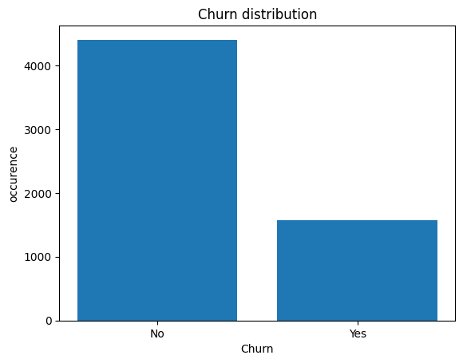

```python
churn_count = df_train['Churn'].value_counts()
plt.bar(churn_count.index, churn_count.values)
plt.xlabel('Churn')
plt.ylabel('occurence')
plt.title('Churn distribution')
plt.show()
```

Our training dataset has more than 4000 customers who don't churn and only less than 2000 cusomers who churn

### 5.2. Visualizing the Curn distribution across different contract types

```python
grouped = df_train.groupby(['Contract', 'Churn']).size().unstack(fill_value=0)
percentages = grouped.div(grouped.sum(axis=1), axis=0) * 100
percentages
```

| Churn Contract | No | Yes |
| --- | --- | --- |
| Month-to-month | 57.418171 | 42.581829 |
| One year | 88.437002 | 11.562998 |
| Two year | 97.321429 | 2.678571 |

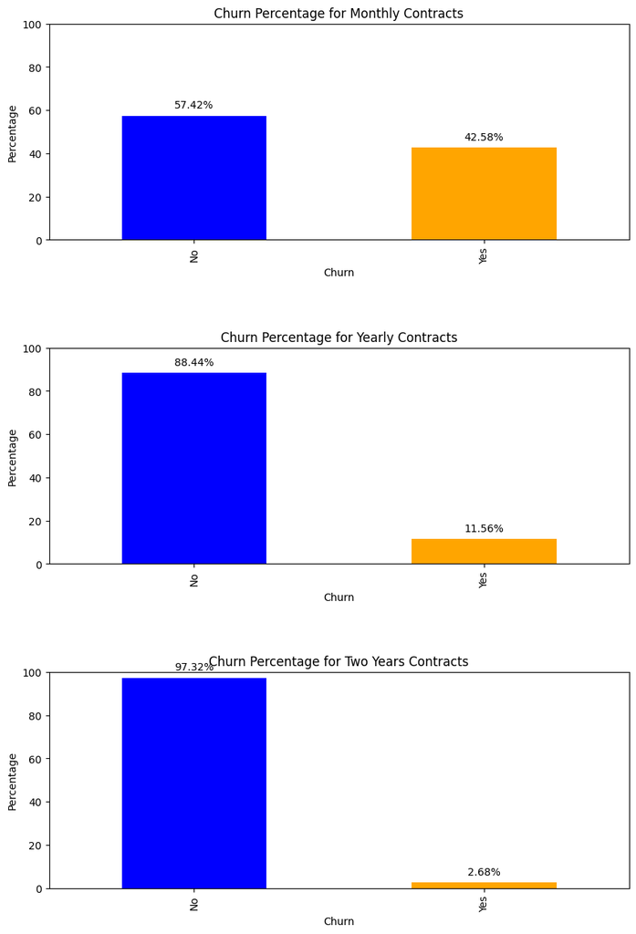

```python
fig, axes = plt.subplots(nrows=3, ncols=1, figsize=(10, 15))
contract_length = ['Month-to-month', 'One year', 'Two year']
titles = ['Monthly', 'Yearly', 'Two Years']

plt.subplots_adjust(hspace=0.5)

for i, contract in enumerate(contract_length):
    ax = axes[i]
    percentages.loc[contract].plot(kind='bar', ax=ax, color=['blue', 'orange'])
    ax.set_title(f'Churn Percentage for {titles[i]} Contracts')
    ax.set_ylabel('Percentage')
    ax.set_xlabel('Churn')
    ax.set_ylim(0, 100)
    for p in ax.patches:
        ax.annotate(f'{p.get_height():.2f}%', (p.get_x() + p.get_width() / 2., p.get_height()), ha='center', va='center', xytext=(0, 10), textcoords='offset points')

plt.show()
```

From the graphs above, we see that there is a bigger churn percentage among clients with shorter contracts

## 6. Feature Engineering

```python
df_train['Churn'] = df_train['Churn'].map({'Yes': 1, 'No': 0})
df_test['Churn'] = df_test['Churn'].map({'Yes': 1, 'No': 0})

X_train = df_train.drop('Churn', axis = 1)
y_train = df_train['Churn']
X_test  = df_test.drop('Churn', axis = 1)
y_test = df_test['Churn']
```

```python
categorical_cols = X_train.select_dtypes(include=['object']).columns
numerical_cols = X_train.select_dtypes(include=['int64','float64']).columns

column_transformer = ColumnTransformer(
    transformers = [('cat', OneHotEncoder(),categorical_cols),
                    ('num', MinMaxScaler(), numerical_cols)
                    ])

column_transformer.fit(X_train)
X_train_encoded = column_transformer.transform(X_train)
X_test_encoded = column_transformer.transform(X_test)

cat_features = column_transformer.transformers_[0][1].get_feature_names_out(categorical_cols)
num_features = column_transformer.transformers_[1][2]
all_features = list(cat_features) + list(num_features)

X_train = pd.DataFrame(X_train_encoded, columns=all_features)
X_test = pd.DataFrame(X_test_encoded, columns=all_features)
```

## 7. Feature Selection using decision trees

```python
grid_parameters = {"criterion": ["gini", "entropy"],
             "min_samples_split": [10, 20, 40],
             "max_depth": [2,3,4],
             "min_samples_leaf": [100, 40, 20, 1],
             "max_leaf_nodes": [20,10,5]}

clf = DecisionTreeClassifier(class_weight = 'balanced')
grid = GridSearchCV(clf, grid_parameters,scoring = 'f1', cv=10)
search=grid.fit(X_train, y_train)
best_tree = search.best_estimator_
best_score = search.best_score_

print( "Best f1 score:", round(best_score * 100, 1), '%')
print( "Optimal hyperparameters:")
print(search.best_params_)
```

```
Best f1 score: 61.7 %
Optimal hyperparameters:
{'criterion': 'gini', 'max_depth': 4, 'max_leaf_nodes': 10, 'min_samples_leaf': 100, 'min_samples_split': 10}
```

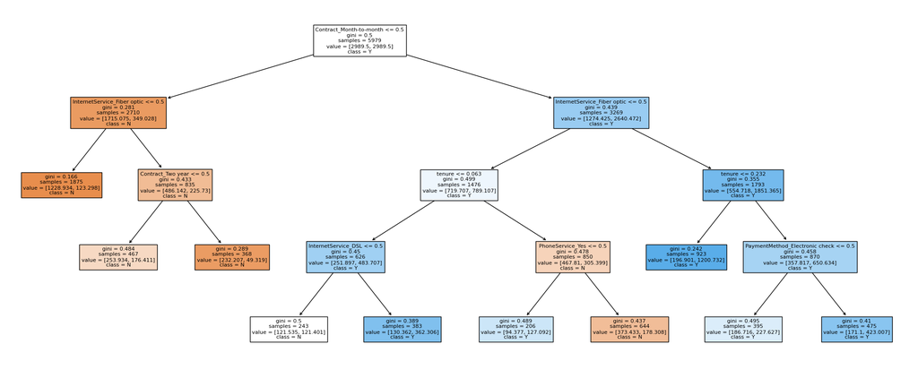

```python
plt.figure(figsize=(25,10))
plot_tree(best_tree, filled=True, feature_names=X_train.columns, class_names=['N', 'Y'])
plt.show()
```

From the decision tree visualization, we conclude the the most important features are 'Contract_month-to-month'and 'InternetService_Fiber optic'. We got these features after appying column_transformer. We will select the features up to the fourth branch of the tree to train our neural network and we will also try to run it without this feature selection step

```python
X_train = X_train[ ['Contract_Month-to-month', 'InternetService_Fiber optic', 'tenure', 'Contract_Two year', 'InternetService_DSL', 'PhoneService_Yes', 'PaymentMethod_Electronic check'] ]
X_test = X_test[ ['Contract_Month-to-month', 'InternetService_Fiber optic', 'tenure', 'Contract_Two year', 'InternetService_DSL', 'PhoneService_Yes', 'PaymentMethod_Electronic check'] ]
```

## 8 Computational experimentation

In this section we split the dataset into training and validation sets, we run the model using different hyperparameters and we choose the best parameters on the test set tom make our predictions. We use f1-score for the class Y = 1 as our evaluation metric, as we are more interested in finding customers who are at more risk of churning

```python
X_train, X_val, y_train, y_val= train_test_split(X_train, y_train, test_size = 0.10, random_state =41)
```

```python
uploaded1 = files.upload()
results = list(uploaded1.keys())[0]
df_results = pd.read_csv(results, sep = ';')
df_results
```

Upload widget is only available when the cell has been executed in the current browser session. Please rerun this cell to enable.

```
Saving Results.csv to Results (4).csv
```

|  | Empty Strings | Merging values | Scaling Features | Feature Selection | Number of layers | First Activation Function | Batch Size | Optimizer | f1-score | Execution time |
| --- | --- | --- | --- | --- | --- | --- | --- | --- | --- | --- |
| 0 | drop rows | yes | yes | yes | 2 | Linear | default | adam | 64,10% | 6,52 |
| 1 | drop rows | yes | yes | yes | 2 | Linear | default | SGD | 62,30% | 5,62 |
| 2 | drop rows | yes | yes | yes | 2 | Linear | 64 | adam | 64,20% | 3,41 |
| 3 | drop rows | yes | yes | yes | 2 | Linear | 128 | adam | 61,50% | 3,85 |
| 4 | drop rows | yes | yes | yes | 2 | tahnh | 64 | adam | 63,10% | 2,96 |
| 5 | drop rows | yes | yes | yes | 3 | linear | 64 | adam | 63,20% | 7,59 |
| 6 | drop rows | yes | yes | no | 2 | linear | 64 | adam | 65,40% | 6,61 |
| 7 | drop rows | yes | no | no | 2 | linear | 64 | adam | 49,40% | 4,34 |
| 8 | drop rows | no | yes | no | 2 | linear | 64 | adam | 62,40% | 2,96 |
| 9 | drop columns | yes | yes | no | 2 | linear | 64 | adam | 61,90% | 3,41 |

Configuration number 6 gave us the best results. Therefore, we run our final model using that configuration

## 9. Final Model

```python
class_weights = compute_class_weight(class_weight='balanced', classes=np.unique(y_train), y=y_train)
class_weights_dict = dict(enumerate(class_weights))

model = Sequential([
Dense(45, input_shape = (38,), activation = 'linear'),
#Dense(1, activation = 'tanh'),
Dense(1, activation = 'sigmoid')
    ])
model.compile(optimizer = 'adam', loss = 'binary_crossentropy')
start_time = time.time()
model.fit(X_train, y_train, epochs = 10, batch_size = 64, validation_data = (X_val, y_val), class_weight=class_weights_dict )
y_test_pred = model.predict(X_test)
y_test_pred = np.where(y_test_pred > 0.5, 1, 0)

end_time = time.time()
execution_time = end_time - start_time

print('Classification report: ')
print(classification_report(y_test, y_test_pred))
print('Execution time: ', execution_time)
```

```
Classification report:
              precision    recall  f1-score   support

           0       0.90      0.73      0.81       760
           1       0.53      0.78      0.63       293

    accuracy                           0.75      1053
   macro avg       0.71      0.76      0.72      1053
weighted avg       0.80      0.75      0.76      1053

Execution time:  3.760685920715332
```

## 11. Limitations:

Although the pipeline is strong overall, we cannot optimize for all the metrics at once and we can only make some tradeoffs to make a pipeline that can make some improvement to the business. In addition, the imbalanced nature of the dataset makes it harder to perform equally well on both classes. Furthermore, even though we have a strong performance, the model is harder to interpret because of the use of neural networks.